# Serpentine Diversity Index Tutorial

Luka Negoita

12/28/2019

### Introduction

This is a tutorial on how to generate diversity indices for your plot data and then run a simple analysis comparing the diversity between treatments.

To begin this project, first open R Studio and go to *File > New Project*, and follow the prompts to create a new project in a custom directory where all of your files will be. Outside of R Studio, I recommend you go into the directory folder where the project file is saved and create a folder for “*data*” and put your CSV file in there. This just helps keep everything organized.

Then in R Studio, go to *File > New File > R* Script to create the script where you can copy and paste the code from this tutorial to follow along.

### Load Packages

The first step is to load all the packages that give us the tools we will need in this script:

```r
# install.packages("vegan") # use this first if the package is not already installed
library("vegan") # package with tools for VEGetation ANalysis
library("tidyverse") # package with essential tools for data cleaning and manipulation
library("lme4") # package for mixed effect models
```

### Upload the data

Now, upload the data from the raw CSV file and separate out the species covers from the rock, etc covers. I don’t know what “Thatch” means, but I’m assuming it’s not a species cover

```r
# Upload the data:
all_dat <- read_csv("data/2018&2019springnsserpcoverdataR.csv")
# Look at the list of species names to see which ones are not species:
unique(all_dat$Species_Name)
```

```
##  [1] "Bare_ground"                 "Dudleya_abramsii_ssp_murina"
##  [3] "Eschscholzia_californica"    "Festuca_perennis"
##  [5] "Hazardia_squarrosa"          "Plantago_erecta"
##  [7] "Rock"                        "Selaginella_bigelovii"
##  [9] "Stipa_lepida"                "Thatch"
## [11] "Astragalus_gambelianus"      "Avena_barbata"
## [13] "Baccharis_pilularis"         "Bareground"
## [15] "Bromus_hordeaceus"           "Bromus_rubens"
## [17] "Crassula_connata"            "Dichelostemma_capitatum"
## [19] "Dudley_abramsii_ssp_murina"  "Malacothrix_sp_(1)"
## [21] "Stipa_pulchra"               "Uropappus_lindleyi"
## [23] "Viola_pedunculata"           "Acmispon_glaber"
## [25] "Calandrinia_menziesii"       "Calochortus_obispoensis"
## [27] "Astragalus_spp"              "Bloomeria_crocea"
## [29] "Euphorbia_spathulata"        "Lasthenia_gracilis"
## [31] "Malacothrix_sp_(2)"          "Sisyrinchium_bellum"
## [33] "Calystegia_macrostegia"      "Corethrogyne_filaginifolia"
## [35] "Allium_haematochiton"        "Chorizanthe_palmeri"
## [37] "Avena_fatua"                 "Cryptantha_clevelandii"
## [39] "Cryptantha_microstachys"     "Chlorogalum_pomeridianum"
## [41] "Acmispon_wrangelianus"       "Koeleria_macrantha"
## [43] "Asteraceae_sp"               "Poaceae_sp"
## [45] "Asteraceae_sp_2"             "Herbaceous_seedling"
## [47] "Allium_lacunosum"            "Trifolium_gracilentum"
## [49] "Malacothrix_glabrata"        "Paeonia_californica"
## [51] "Trifolium_depauperatum"      "Delphinium_parryi"
## [53] "Stebbinsoseris_heterocarpa"  "Lepidium_nitidum"
## [55] "Hesperevax_sparsiflora"      "Stipa_sp"
## [57] "Primula_clevelandii"         "Silene_gallica"
## [59] "Acmispon_junceus"
```

```r
# Extract just the non-species covers:
non_spp_cov <- filter(all_dat,
                      grepl("Rock",Species_Name) | # the '|' operator means OR
                      grepl("Thatch",Species_Name) |
                      grepl("ground",Species_Name))
# 'grepl()' searches for a text pattern within a vector, in this case "Species_Name"

# And here extract just the species covers:
spp_cov <- filter(all_dat,
                      !grepl("Rock",Species_Name) & # the '&' operator means AND
                      !grepl("Thatch",Species_Name) &
                      !grepl("ground",Species_Name))
# the '!' operator means NOT, meaning that it reverses TRUE and FALSE, thus where is "Rock" NOT found...
```

### Adjust the plot covers

Now, we need to adjust the total area of each plot to the proportion of the plot within which a plant can actually grow. Saying that a certain species covers only 60% of a plot is misleading if 40% of the plot is bare rock. That species should actually be treated as covering 100% of the “livable” area of the plot. Note that in some cases species may have over 100% cover (since they can spread over the rock area), but this is fine and will not affect the calculation of diversity indices.

To adjust the plot covers, first summarize the average rock cover for each plot (since it was measured twice for the same plot sometimes), and convert it to soil cover (the inverse of rock cover):

```r
soil_cover <- group_by(non_spp_cov, Plot_Name) %>% # within each Plot_Name...
  summarize(Q1.soil = 100-mean(Q1), # summarize each subplot rock cover and convert to soil cover
            Q2.soil = 100-mean(Q2),
            Q3.soil = 100-mean(Q3),
            Q4.soil = 100-mean(Q4))
```

Next, join those soil covers to the species covers:

```r
spp_cov_all <- left_join(spp_cov, soil_cover, by="Plot_Name")
```

Finally, adjust the species covers according to these soil covers by dividing each species cover by the total potential grow-able area (the soil covers we had just calculated):

```r
# Adjust the species covers according to the soil covers.
# also multiply by 100 to keep in percentage units and round to the nearest percentage unit
spp_cov_adj <- mutate(spp_cov_all,
                      Q1 = round((Q1/Q1.soil)*100),
                      Q2 = round((Q2/Q2.soil)*100),
                      Q3 = round((Q3/Q3.soil)*100),
                      Q4 = round((Q4/Q4.soil)*100),
                      Mean_Cover = (Q1+Q2+Q3+Q4)/4)
# also recalculate total cover, which I've renamed to mean cover since that's actually what it means
```

### Create species X plot matrix

Now to calculate diversity indices we need to create a complete matrix of all species in each site. The matrix is complete because species that did not occur in a particular plot are simply assigned a value of zero. For this analysis, I calculate everything at the quad or subplot level since we can run the analyses on that level for extra power (larger sample size), and we make up for the pseudoreplication of four data points (quads) within each plot by include “plot” as a random effect–but more on that later…

```r
# Clean up the data frame by selecting only the useful columns
spp_cov_fin <- select(spp_cov_adj, -contains("soil"), -Total_Cover, -Mean_Cover) %>%
  gather(quad, cover, Q1:Q4) %>%
  mutate(year_subplot = paste(Year,Plot_Name,quad,sep="_")) #

# Now, save just the plot-level data separately (used for analyses later):
plot_data <- select(spp_cov_fin, -Species_Name, -Date, -Season, -cover, -quad) %>%
  unique()

# Extract just the cover data for each year_subplot and create a matrix.
# Note that in some cases you entered a cover more than once for the
# same species in the same plot on the same date. Because of that, I
# just average the values. If you think those are data entry mistakes,
# you can just fix them in the original data.
covers <- select(spp_cov_fin, -Date, -Season, -Substrate, -Treatment,
                 -Aspect, -Plot, -Year, -Plot_Name, -quad) %>%
  group_by(Species_Name, year_subplot) %>%
  summarize(cover = mean(cover)) %>%
  spread(key=Species_Name, value=cover, fill=0)

# Convert covers to a matrix and add year_subplot as row_names,
# then remove the year_subplot name column:
spp_plot <- data.matrix(covers)
row.names(spp_plot) <- covers$year_subplot
spp_plot <- spp_plot[,-1] # only run this line once or you'll delete each following first column
```

### Calculate Diversity Indices

Now we can get on with actually calculating the diversity indices. First, make a custom function for the Shannon an Simpson indices to make it easier to use them with the *apply* function:

```r
# define our own diversity functions:
shan <- function(x) diversity(x, index="shannon")
simp <- function(x) diversity(x, index="simpson")
```

Now, calculate diversity indices for each row (year_plot_subplot combo) in the matrix:

```r
# Use the apply function to apply each diversity function to all the rows (MARGIN = 1) in the matrix
shannon_div <- apply(spp_plot, MARGIN=1, FUN=shan)
simpson_div <- apply(spp_plot, MARGIN=1, FUN=simp)

# Then create a data frame (actually called a tibble when using the Tidy package) with these results:
plot_div <- tibble(year_subplot = names(shannon_div), shannon = shannon_div, simpson = simpson_div)

plot_div
```

```
## # A tibble: 144 x 3
##    year_subplot   shannon simpson
##    <chr>            <dbl>   <dbl>
##  1 2018_NS-BS1_Q1   1.89    0.832
##  2 2018_NS-BS1_Q2   1.47    0.694
##  3 2018_NS-BS1_Q3   1.82    0.803
##  4 2018_NS-BS1_Q4   1.66    0.770
##  5 2018_NS-BS2_Q1   1.28    0.584
##  6 2018_NS-BS2_Q2   1.38    0.711
##  7 2018_NS-BS2_Q3   0.937   0.462
##  8 2018_NS-BS2_Q4   1.90    0.789
##  9 2018_NS-BS3_Q1   1.70    0.759
## 10 2018_NS-BS3_Q2   1.55    0.724
## # … with 134 more rows
```

Finally, append these results back to the plot data, and fix up the dataframe for analysis

```r
# Finally, append these results back to the plot data, and fix up the dataframe for analysis
final_data <- left_join(plot_data, plot_div, by="year_subplot") %>%
  select(-year_subplot, -Plot) %>% # don't need the year_plot column (or "plot") anymore
  mutate(Plot_Name = as.factor(Plot_Name), # these columns need to be converted to factors
         Substrate = as.factor(Substrate),
         Treatment = as.factor(Treatment),
         Year = as.factor(Year),
         Aspect = as.factor(Aspect))
```

### Basic Analysis

Now the fun begins! We can start by simply making a boxplot of the Shannon index as a function of treatment, for example:

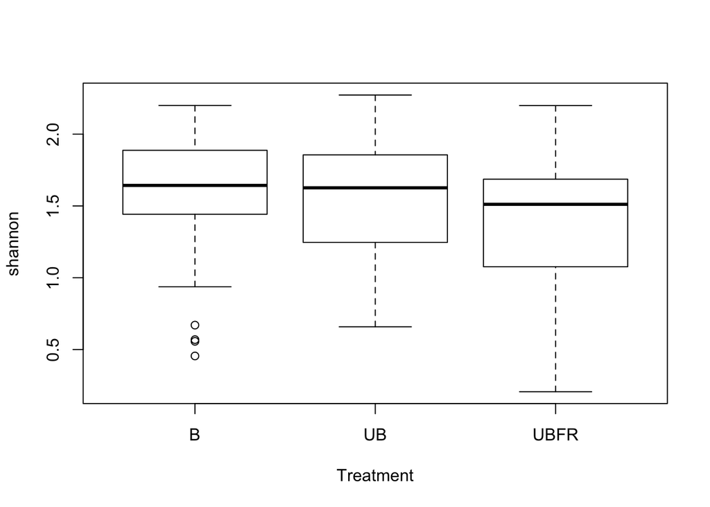

```r
# Basic plot of Shannon index for each treatment
plot(shannon~Treatment, data=final_data)
```

The this preliminary plot suggest there might be a treatment effect on the Shannon index, but time (year) is also important since one would assume it takes time for each treatment to take effect. Thus, the real question we are interested in is whether there is a significant interaction effect between treatment and time. If my logic here doesn’t make sense, it’s either because I don’t understand the exact experimental design (my assumption is that the 2018 measures are baseline, and 2019 is after the treatments have taken effect), or I am not explaining this well enough. Either way, let’s discuss this more if it isn’t clear.

Now let’s build two models, one that includes the desired interaction effect and one that excludes it. We can’t immediately get P-values from a mixed effect model like we can with a basic model, so we have to use a likelihood ratio test that compared two models–that’s what gets us a P-value.

```r
# General Mixed-effect regression model with interaction effect:
mod_interaction <- lmer(shannon~Treatment+Year+Treatment*Year+(1|Plot_Name), data=final_data, REML=F)
# REML = F is hard to explain, but just know this argument is important for us to be able to compare this to the NULL model in the next step

# General Mixed-effect regression model WITHOUT interaction effect:
mod_null <- lmer(shannon~Treatment+Year+(1|Plot_Name), data=final_data, REML=F)
```

And now perform the likelihood-ratio test of comparing these models. A significant result (P-value less than 0.05) indicates that the two models are significantly different in their ability to fit your data, indicating that the parameter missing from the null model is a significantly important component of the full model. In other words, the interaction effect is significant, meaning that treatment has a significant effect on diversity.

```r
# Perform a likelihood ratio test using Chi-squared test to see if the models are significantly different
# don't be confused by the function being "anova()". It has nothing to do with an ANOVA test...
anova(mod_interaction,mod_null)
```

```
## Data: final_data
## Models:
## mod_null: shannon ~ Treatment + Year + (1 | Plot_Name)
## mod_interaction: shannon ~ Treatment + Year + Treatment * Year + (1 | Plot_Name)
##                 Df    AIC    BIC  logLik deviance  Chisq Chi Df Pr(>Chisq)
## mod_null         6 99.794 117.61 -43.897   87.794
## mod_interaction  8 99.098 122.86 -41.549   83.098 4.6958      2    0.09557
##
## mod_null
## mod_interaction .
## ---
## Signif. codes:  0 '***' 0.001 '**' 0.01 '*' 0.05 '.' 0.1 ' ' 1
```

Looks like there is no significant interaction effect. Let’s just test the effect of treatment without including interactions:

```r
# General Mixed-effect regression model with treatment effect:
mod_treatment <- lmer(shannon~Treatment+Year+(1|Plot_Name), data=final_data, REML=F)

# General Mixed-effect regression model WITHOUT treatment effect:
mod_null <- lmer(shannon~Year+(1|Plot_Name), data=final_data, REML=F)

# Likelihood ratio test:
anova(mod_treatment,mod_null)
```

```
## Data: final_data
## Models:
## mod_null: shannon ~ Year + (1 | Plot_Name)
## mod_treatment: shannon ~ Treatment + Year + (1 | Plot_Name)
##               Df    AIC    BIC  logLik deviance  Chisq Chi Df Pr(>Chisq)
## mod_null       4 98.223 110.10 -45.112   90.223
## mod_treatment  6 99.794 117.61 -43.897   87.794 2.4292      2     0.2968
```

Still no significant effect…

### Conclusion and next steps

One next step to take (as you mentioned with the Tukey test) is to do a pairwise comparison of each treatment to each other treatment with a P-value adjustment to account for the many tests.

You also mentioned comparing native or invasive grasses? All we need is a column in the data set that indicates whether each species is native or not. Then the exact same code can be run and at the end just do something along the lines of:

```r
lmer(shannon ~ Treatment + Year + Nativity + (1|Plot_Name), data=final_data, REML=F)
```

Hope this helps! Of course let me know if you have any questions.